# Classification of the Rate of Return to Homelessness in the Travis County 2017-2021.

2023-11-29

# City of Austin Project

## Rates of Returns to Homelessness

Introduction: The Travis County Continuum of Care, (CoC) has recently seen the challenges of homelessness as it impacts urban planning and discussion. Homelessness has taken center stage in urban planning and social welfare. The returns data set sheds light on those individuals who, after obtaining permanent housing, returned to homelessness within a mere span from the recorded years 2017-2021.Each unique row in this dataset represents a specific demographic, i.e., White, disabled, or veteran in a particular fiscal year from 2017 to 2021.

Our motivation for selecting these data sets is the increasing need to understand the efficacy of CoC interventions in addressing homelessness. A study by [Alexander-Eitzman, 2013], delved into the complexities surrounding homelessness in urban settings and emphasized the importance of long-term solutions rather than just immediate relief *[1]*. The context offered by this previous study magnifies the significance of our data sets, especially as we look at the variables of interest: the rate of return to homelessness and exits from homelessness, the associated factors that might influence these rates such as the specific demographic, and the type of housing before homelessness. We anticipate certain demographic patterns that might influence an individual’s likelihood of returning to homelessness after a seemingly successful exit. We will investigate this by comparing the rates of returns of these specific demographics: race and ethnicity, age, gender, disability status, and veteran status all noted within the span of 2017-2021.

Through our exploratory data analysis, we aim to answer pivotal research questions such as: *What demographic factors correlate with a higher likelihood of returning to homelessness?* *What type of prior housing results in fewer returns to homelessness?* *How do successful returns from homelessness vary across different fiscal years?*

Using our classification and prediction models, we will predict the rate of return to homelessness based on specific demographic, fiscal year, and type of housing before homelessness, and perform a five-fold cross-validation for each model.

**Import the return dataset. Explore the dimensions of the dataset.**

```r
# Import return dataset
library(readr)
returns <- read_csv("Strategic_Measure_Number_of_returns_to_homelessness (1).csv")

# Explore the `returns` dataset
str(returns)
```

```
## spc_tbl_ [591 × 9] (S3: spec_tbl_df/tbl_df/tbl/data.frame)
##  $ Demographic Category  : chr [1:591] "Race" "Race" "Race" "Race" ...
##  $ Specific Demographic  : chr [1:591] "American Indian or Alaskan Native" "Asian" "Black or African American" "Native Hawaiian or Other Pacific Islander" ...
##  $ Fiscal Year           : num [1:591] 2017 2017 2017 2017 2017 ...
##  $ SO/ES/TH/SH/PH        : chr [1:591] "SO" "SO" "SO" "SO" ...
##  $ Numerator             : num [1:591] 0 0 0 0 0 0 0 0 0 0 ...
##  $ Denominator           : num [1:591] 0 0 0 0 0 0 0 0 0 0 ...
##  $ Rate                  : num [1:591] 0 0 0 0 0 0 0 0 0 0 ...
##  $ Fiscal Year Start Date: chr [1:591] "10/01/2016 12:00:00 AM" "10/01/2016 12:00:00 AM" "10/01/2016 12:00:00 AM" "10/01/2016 12:00:00 AM" ...
##  $ Fiscal Year End Date  : chr [1:591] "09/30/2017 12:00:00 AM" "09/30/2017 12:00:00 AM" "09/30/2017 12:00:00 AM" "09/30/2017 12:00:00 AM" ...
##  - attr(*, "spec")=
##   .. cols(
##   ..   `Demographic Category` = col_character(),
##   ..   `Specific Demographic` = col_character(),
##   ..   `Fiscal Year` = col_double(),
##   ..   `SO/ES/TH/SH/PH` = col_character(),
##   ..   Numerator = col_double(),
##   ..   Denominator = col_double(),
##   ..   Rate = col_double(),
##   ..   `Fiscal Year Start Date` = col_character(),
##   ..   `Fiscal Year End Date` = col_character()
##   .. )
##  - attr(*, "problems")=<externalptr>
```

```r
dim(returns)
```

```
## [1] 591   9
```

**Using the recode function inside a mutate, change the names of the labels under the variables `SO/ES/TH/SH/PH`, `Specific Demographic`, and `Demographic Category` to make the variables easily comprehensible. Create a new variable `PriorHousing` with the mutate() function with the recoded names under the `SO/ES/TH/SH/PH` variable. Also using filter(), remove all unknowns.**

```r
returns |>
  mutate("Specific Demographic" = recode(`Specific Demographic`, "AmIndAKNative" = "American Indian or Alaskan Native", "BlackAfAmerican" = "Black or African American", "Client Doesn't Know or Client Refused" = "Unknown", "NativeHIOtherPacific" = "Native Hawaiian or Other Pacific Islander", "NativeHIPacific" = "Native Hawaiian or Other Pacific Islander", "Gender non-conforming"="Gender Non-Conforming", "Elder Adult 62+"="Adult 62+", "Not a Veteran"="No", "Veteran"="Yes", "Adult under 62"="Adult 25-61", "Elder Adult"="Adult 62+", "Young Adult"="Adult 18-24", "Does Not Have a Disabling Condition"="No", "Has a Disabling Condition"="Yes"))|>
    mutate(`SO/ES/TH/SH/PH`=recode(`SO/ES/TH/SH/PH`, "Sh"="SH", "So"="SO"))|>
    mutate(PriorHousing=recode(`SO/ES/TH/SH/PH`, "SO"= "Street Outreach", "ES"= "Emergency Shelter", "TH"= "Transitional Housing", "SH"="Safe Haven", "PH"="Permanent Housing")) |>
    mutate("Demographic Category" = recode(`Demographic Category`, "Age"="Age Category", "Disability"="Disability Status", "Veteran"="Veteran Status")) |>
    filter(`Specific Demographic`!="Unknown") -> returns #saved as the same variable to override the first one

#Look at the results of the tyding
dim(returns)
```

```
## [1] 467  10
```

**After cleaning the data, there are now 467 observations and 10 variables in the returns data set. Any further attempts to wrangle the data set by pivoting wider or longer would lead to an excessive number of missing values, therefore the data is as tidy as it can be.**

# Results

## Descriptive Statistics

**Grouped by `Demographic Category` and `Specific Category`, found the mean rates and standard deviation for the `returns` data set. Use the arrange function to find the highest rates among the demographics.**

```r
#mean and standard deviation return rate per demographic
returns|>
  group_by(`Demographic Category`, `Specific Demographic`)|>
  summarise(mean_rate=mean(Rate,na.rm=T), sd_rate=sd(Rate,na.rm=T))|>
  arrange(desc(mean_rate))
```

```
## # A tibble: 22 × 4
## # Groups:   Demographic Category [6]
##    `Demographic Category` `Specific Demographic`    mean_rate sd_rate
##    <chr>                  <chr>                         <dbl>   <dbl>
##  1 Race                   Two or more races             0.25   0.191
##  2 Veteran Status         Yes                           0.242  0.193
##  3 Disability Status      Yes                           0.241  0.132
##  4 Race                   White                         0.236  0.267
##  5 Age Category           Adult 25-61                   0.224  0.141
##  6 Ethnicity              Non-Hispanic/Non-Latino       0.210  0.0927
##  7 Age Category           Adult 62+                     0.209  0.228
##  8 Gender                 Male                          0.208  0.103
##  9 Race                   Black or African American     0.207  0.119
## 10 Veteran Status         No                            0.194  0.203
## # ℹ 12 more rows
```

## Univariate Plots

### Figure 1.1: Univariate Plot of Distribution of Demographic Categories

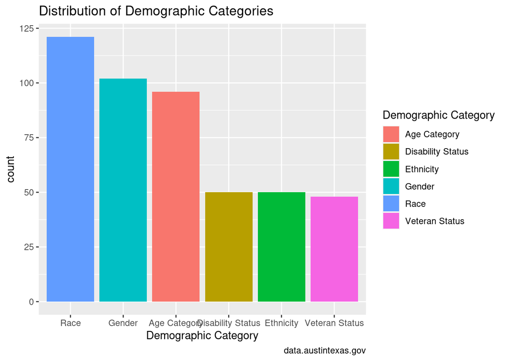

```r
#bar graph of distribution of demographic categories in `returns`

returns |>
  group_by(`Demographic Category`) |>
  count() |>
  mutate(count=n) |>
  ggplot(aes(x=reorder(`Demographic Category`, -count), y=count)) +
  geom_bar(stat="identity", aes(fill=`Demographic Category`))+
  labs(title = "Distribution of Demographic Categories", x = "Demographic Category", caption="data.austintexas.gov", fill = "Demographic Category")
```

### Figure 1.2: Univariate Plot of Rate of Returns

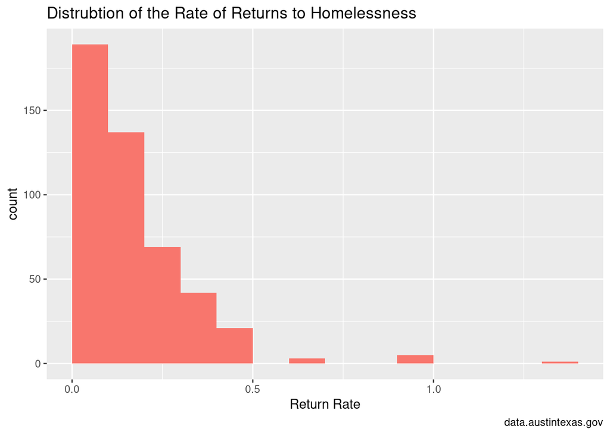

```r
#  histogram of returns to homelessnes
returns|>
  ggplot(aes(x=Rate))+
  geom_histogram(aes(fill="red"), binwidth = .1, center=.05)+
  # the fill color does not represent another variable
  labs(x="Return Rate", title="Distrubtion of the Rate of Returns to Homelessness", caption="data.austintexas.gov")+
  theme(legend.position = "none")
```

## Visuals for Returns

### Figure 2.1: Bivariate Plot of Race/Ethnicity and Return Rate

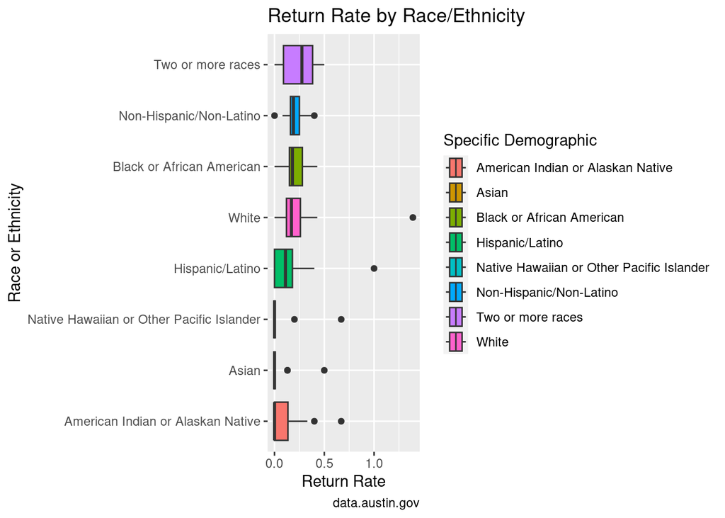

```r
#boxplot of rate of return by race/ethnicity
returns|>
   filter(`Demographic Category`=="Race" | `Demographic Category`=="Ethnicity")|>
  # order the boxplots by highest to lowest median return rate
  ggplot(aes(y=reorder(`Specific Demographic`, Rate, FUN=median),x=Rate))+
  geom_boxplot(aes(fill=`Specific Demographic`))+
  labs(title="Return Rate by Race/Ethnicity", x="Return Rate", y="Race or Ethnicity", caption = "data.austin.gov", fill = "Specific Demographic")
```

### Figure 2.2: Bivariate Plot of Disability Status and Return Rate

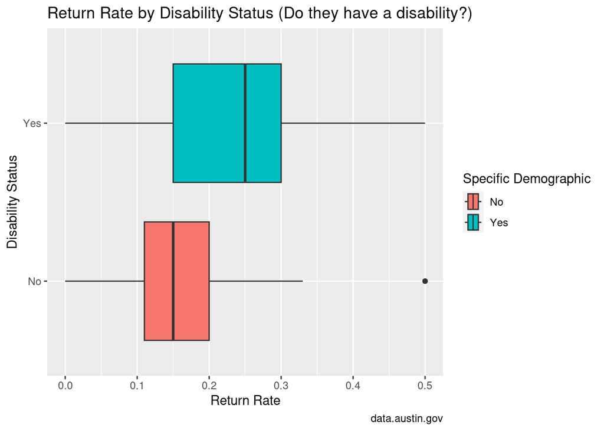

```r
#boxplot of disability status return rate
returns|>
   filter(`Demographic Category`=="Disability Status")|>
  ggplot(aes(y=`Specific Demographic`,x=Rate))+
  geom_boxplot(aes(fill=`Specific Demographic`))+
  labs(title="Return Rate by Disability Status (Do they have a disability?)", x="Return Rate", y="Disability Status", caption = "data.austin.gov", fill = "Specific Demographic")
```

### Figure 2.3: Bivariate Plot of Veteran Status and Return Rate

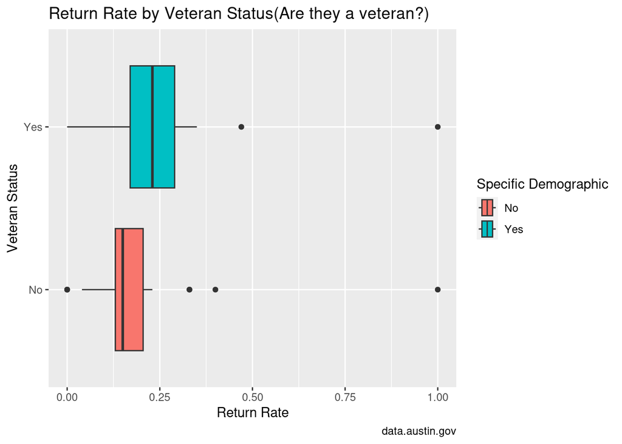

```r
#boxplot of veteran status return rate
returns|>
   filter(`Demographic Category`=="Veteran Status")|>
  ggplot(aes(y=`Specific Demographic`,x=Rate))+
  geom_boxplot(aes(fill=`Specific Demographic`))+
  labs(title="Return Rate by Veteran Status(Are they a veteran?)", x="Return Rate", y="Veteran Status", caption = "data.austin.gov", fill = "Specific Demographic")
```

### Figure 3.1: Boxplot of Return Rates in each Prior Housing Type

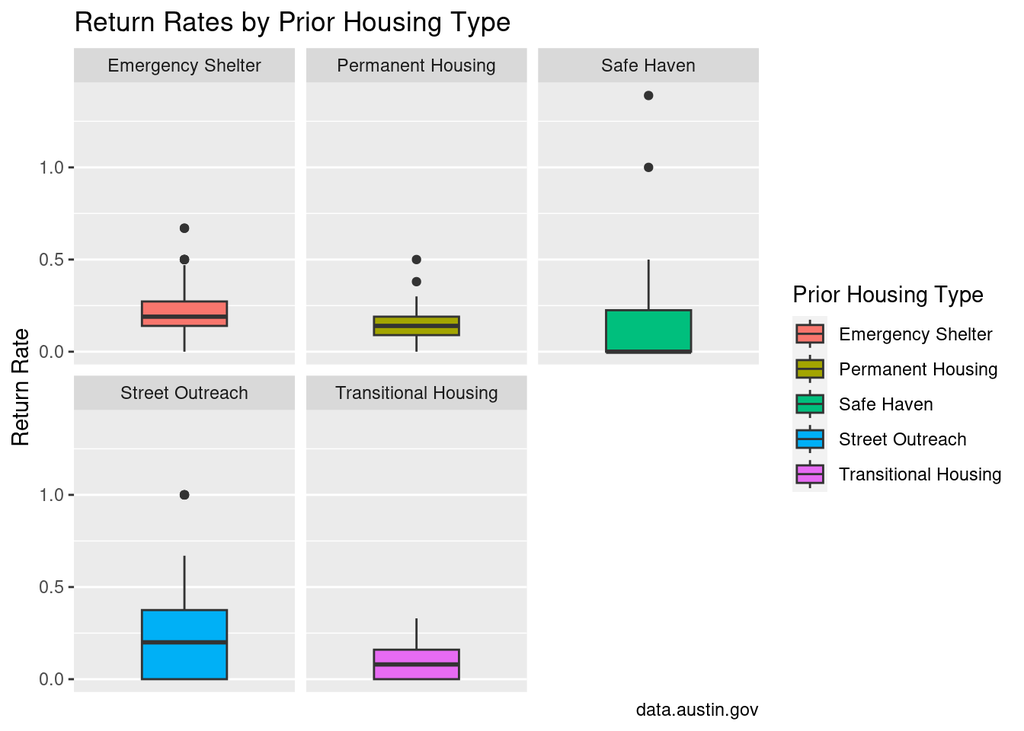

```r
# boxplot visual of return rates per `PriorHousing`
returns|>
  group_by(`Demographic Category`, `Specific Demographic`)|>
  select(`Demographic Category`, `Specific Demographic`, Rate, PriorHousing)|>
  ggplot()+
  geom_boxplot(aes(y=Rate,fill=PriorHousing))+
  facet_wrap(~PriorHousing)+
  scale_x_discrete() +
  labs(fill="Prior Housing Type", caption="data.austin.gov", title="Return Rates by Prior Housing Type", y="Return Rate")
```

### Figure 3.2: Boxplot of Return Rates by Fiscal Year

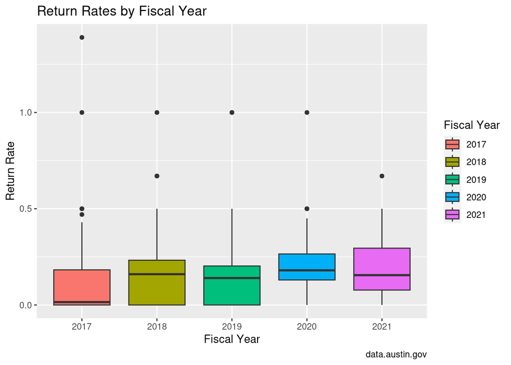

```r
# Grouped boxplot of the return rate by fiscal year
returns|>
  ggplot(aes(x=as.factor(`Fiscal Year`),y=Rate))+
  geom_boxplot(aes(fill=as.factor(`Fiscal Year`)))+
  labs(title="Return Rates by Fiscal Year", x="Fiscal Year", y="Return Rate", caption = "data.austin.gov", fill="Fiscal Year")
```